[figure not shown]

# Random Forest - Classification

## The Data

We will be using the same dataset through our discussions on classification with tree-methods (Decision Tree,Random Forests, and Gradient Boosted Trees) in order to compare performance metrics across these related models.

We will work with the "Palmer Penguins" dataset, as it is simple enough to help us fully understand how changing hyperparameters can change classification results.

[figure not shown]

Data were collected and made available by Dr. Kristen Gorman and the Palmer Station, Antarctica LTER, a member of the Long Term Ecological Research Network.

Gorman KB, Williams TD, Fraser WR (2014) Ecological Sexual Dimorphism and Environmental Variability within a Community of Antarctic Penguins (Genus Pygoscelis). PLoS ONE 9(3): e90081. doi:10.1371/journal.pone.0090081

Summary: The data folder contains two CSV files. For intro courses/examples, you probably want to use the first one (penguins_size.csv).

- penguins_size.csv: Simplified data from original penguin data sets. Contains variables:
  - species: penguin species (Chinstrap, Adélie, or Gentoo)
  - culmen_length_mm: culmen length (mm)
  - culmen_depth_mm: culmen depth (mm)
  - flipper_length_mm: flipper length (mm)
  - body_mass_g: body mass (g)
  - island: island name (Dream, Torgersen, or Biscoe) in the Palmer Archipelago (Antarctica)
  - sex: penguin sex
- (Not used) penguins_lter.csv: Original combined data for 3 penguin species

Note: The culmen is "the upper ridge of a bird's beak"

**Our goal is to create a model that can help predict a species of a penguin based on physical attributes, then we can use that model to help researchers classify penguins in the field, instead of needing an experienced biologist**

## Imports

```python
import numpy as np
import pandas as pd
import matplotlib.pyplot as plt
import seaborn as sns
```

```python
df = pd.read_csv("../DATA/penguins_size.csv")
```

```python
df = df.dropna()
df.head()
```

|  | species | island | culmen_length_mm | culmen_depth_mm | flipper_length_mm | body_mass_g | sex |
| --- | --- | --- | --- | --- | --- | --- | --- |
| 0 | Adelie | Torgersen | 39.1 | 18.7 | 181.0 | 3750.0 | MALE |
| 1 | Adelie | Torgersen | 39.5 | 17.4 | 186.0 | 3800.0 | FEMALE |
| 2 | Adelie | Torgersen | 40.3 | 18.0 | 195.0 | 3250.0 | FEMALE |
| 4 | Adelie | Torgersen | 36.7 | 19.3 | 193.0 | 3450.0 | FEMALE |
| 5 | Adelie | Torgersen | 39.3 | 20.6 | 190.0 | 3650.0 | MALE |

## Train | Test Split

```python
X = pd.get_dummies(df.drop('species',axis=1),drop_first=True)
y = df['species']
```

```python
from sklearn.model_selection import train_test_split
```

```python
X_train, X_test, y_train, y_test = train_test_split(X, y, test_size=0.3, random_state=101)
```

# Random Forest Classification

```python
from sklearn.ensemble import RandomForestClassifier
```

```python
help(RandomForestClassifier)
```

[output not shown]

[output cut: 362 more lines]

[output not shown]

```python
# Use 10 random trees
model = RandomForestClassifier(n_estimators=10,max_features='auto',random_state=101)
```

```python
model.fit(X_train,y_train)
```

```
RandomForestClassifier(n_estimators=10, random_state=101)
```

```python
preds = model.predict(X_test)
```

## Evaluation

```python
from sklearn.metrics import confusion_matrix,classification_report,plot_confusion_matrix,accuracy_score
```

```python
confusion_matrix(y_test,preds)
```

```
array([[39,  2,  0],
       [ 1, 22,  0],
       [ 0,  0, 37]], dtype=int64)
```

```
<sklearn.metrics._plot.confusion_matrix.ConfusionMatrixDisplay at 0x1384588b0d0>
```

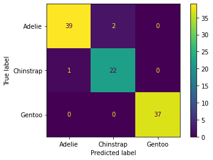

```python
plot_confusion_matrix(model,X_test,y_test)
```

## Feature Importance

Very useful attribute of the trained model!

```python
model.feature_importances_
```

```
array([0.35324545, 0.13320651, 0.1985798 , 0.12074795, 0.14244127,
       0.03781403, 0.00677831, 0.00718669])
```

## Choosing correct number of trees

Let's explore if continually adding more trees improves performance...

```python
test_error = []

for n in range(1,40):
    # Use n random trees
    model = RandomForestClassifier(n_estimators=n,max_features='auto')
    model.fit(X_train,y_train)
    test_preds = model.predict(X_test)
    test_error.append(1-accuracy_score(test_preds,y_test))
```

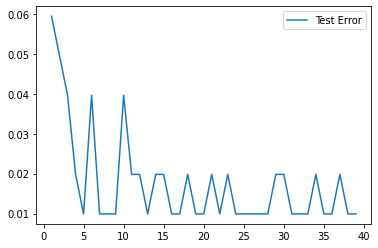

```python
plt.plot(range(1,40),test_error,label='Test Error')
plt.legend()
```

Clearly there are diminishing returns, on such a small dataset, we've pretty much extracted all the information we can after about 5 trees.

# Random Forest - HyperParameter Exploration

https://archive.ics.uci.edu/ml/datasets/banknote+authentication

```python
df = pd.read_csv("../DATA/data_banknote_authentication.csv")
```

```python
df.head()
```

|  | Variance_Wavelet | Skewness_Wavelet | Curtosis_Wavelet | Image_Entropy | Class |
| --- | --- | --- | --- | --- | --- |
| 0 | 3.62160 | 8.6661 | -2.8073 | -0.44699 | 0 |
| 1 | 4.54590 | 8.1674 | -2.4586 | -1.46210 | 0 |
| 2 | 3.86600 | -2.6383 | 1.9242 | 0.10645 | 0 |
| 3 | 3.45660 | 9.5228 | -4.0112 | -3.59440 | 0 |
| 4 | 0.32924 | -4.4552 | 4.5718 | -0.98880 | 0 |

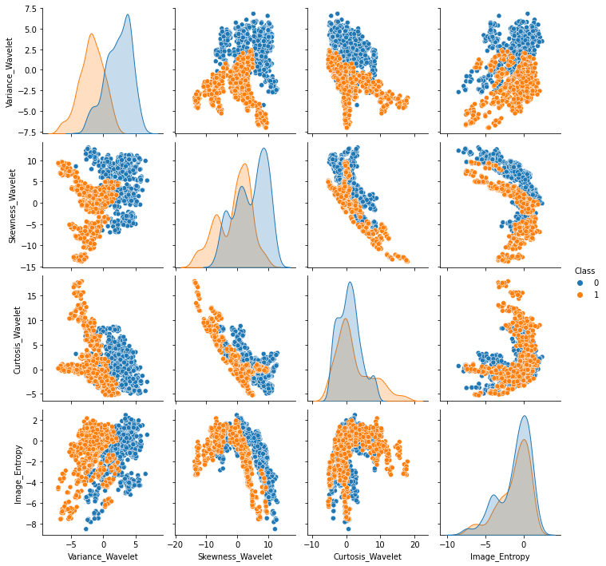

```python
sns.pairplot(df,hue='Class')
```

```python
X = df.drop("Class",axis=1)
```

```python
y = df["Class"]
```

```python
from sklearn.model_selection import train_test_split
```

```python
X_train, X_test, y_train, y_test = train_test_split(X, y, test_size=0.15, random_state=101)
```

```python
from sklearn.model_selection import GridSearchCV
```

```python
n_estimators=[64,100,128,200]
max_features= [2,3,4]
bootstrap = [True,False]
oob_score = [True,False]
```

```python
param_grid = {'n_estimators':n_estimators,
             'max_features':max_features,
             'bootstrap':bootstrap,
             'oob_score':oob_score}  # Note, oob_score only makes sense when bootstrap=True!
```

```python
rfc = RandomForestClassifier()
grid = GridSearchCV(rfc,param_grid)
```

```python
grid.fit(X_train,y_train)
```

[output not shown]

[output cut: 485 more lines]

[output not shown]

[output not shown]

```python
grid.best_params_
```

[output not shown]

```python
predictions = grid.predict(X_test)
```

```python
print(classification_report(y_test,predictions))
```

```
              precision    recall  f1-score   support

           0       1.00      0.98      0.99       124
           1       0.98      1.00      0.99        82

    accuracy                           0.99       206
   macro avg       0.99      0.99      0.99       206
weighted avg       0.99      0.99      0.99       206
```

```
<sklearn.metrics._plot.confusion_matrix.ConfusionMatrixDisplay at 0x138493358e0>
```

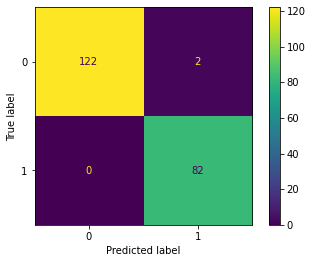

```python
plot_confusion_matrix(grid,X_test,y_test)
```

```python
# No underscore, reports back original oob_score parameter
grid.best_estimator_.oob_score
```

```
True
```

```python
# With underscore, reports back fitted attribute of oob_score
grid.best_estimator_.oob_score_
```

```
0.9939965694682675
```

## Understanding Number of Estimators (Trees)

Let's plot out error vs. Number of Estimators

```python
from sklearn.metrics import accuracy_score
```

```python
errors = []
misclassifications = []

for n in range(1,64):
    rfc = RandomForestClassifier( n_estimators=n,bootstrap=True,max_features= 2)
    rfc.fit(X_train,y_train)
    preds = rfc.predict(X_test)
    err = 1 - accuracy_score(preds,y_test)
    n_missed = np.sum(preds != y_test) # watch the video to understand this line!!
    errors.append(err)
    misclassifications.append(n_missed)
```

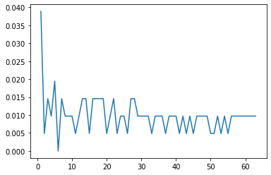

```python
plt.plot(range(1,64),errors)
```

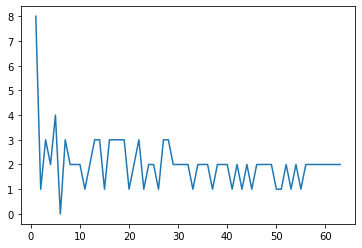

```python
plt.plot(range(1,64),misclassifications)
```